# Weekly assignment 1

Xiyu Zhang

08/29/2022

This is an R Markdown file. Below there are several things that I will ask you to add or modify. Along the way, I’m going to include new R Markdown methods to help expand your R Markdown toolkit.

**[0.5 points]** Please start by editing the YAML section above. Add your own name and the date that you completed this assignment.

**[0.5 points]** Please save this document in your project folder, inside of the `assignments` folder with the naming convention “assignment_1_[your last name]_[your first name].rmd”. In other words, I would save this file as “assignment_1_Evans_Brian.rmd”.

**Important!** Before knitting this file, we’ll have to add a couple of libraries to your project packages (packrat). Please run the following in your console pane:

```r
install.packages(
  c('kableExtra',
    'DT',
    'tidyverse'))
```

The above is called a “code chunk”.

In the curly brackets (`{}`) in your Markdown document:

- The first argument species the program that you are calling, which is in this case `r`.
- The second argument, which is separate by a space from your program argument, provides a label for your code chunk.
- The next argument, separated by a comma, provides chunk options. In this example, it’s saying not to run the code chunk in R. *Note: If eval were set to TRUE, it would try to install the packages each time the document is knit!!*

*Note: the html tag `<hr>` below creates a horizontal line.*

## Code chunks

The code chunk below is the setup section for the code chunks in the document. Code chunks begin with three back-ticks, then curly braces, a set of instructions for the chunk, and options for running the chunk or styling the output. The instructions here say to run Program R, call the chunk “setup”, and don’t include the code in the knitted document. Knit the document to see how it looks.

```r
knitr::opts_chunk$set(echo = TRUE)
```

The code chunk below loads the tidyverse meta-package. This is necessary, because it allows the document to call on tidyverse functions and data.

Note that the chunk option `message=TRUE` is actually the default behavior. Change this option to FALSE and knit the document to see what happens. **[0.5 points]**

```r
library(tidyverse)

a <- 1 + 2

a
```

```
## [1] 3
```

### Add a new code chunk

The data set `fruit` is a character vector that became available in this session if you correctly loaded the tidyverse package.

Insert a new code chunk (Windows: Ctrl+Alt+I, Mac: Command+Option+I). Inside the chunk, use indexing to subset the `fruit` vector to the first four values and assign the name `my_fruit` to the resultant object. **[0.5 points]**

```r
my_fruit <- fruit[1:4]
```

### Code chunks for styling css:

We can use code chunks to modify the css of our document (cascading style sheet). Below, I’ve added some styling to this document using css **but** I’ve commented out each style element. For each style element knit the document then un-comment that section and knit it again to see how the document changes. **[1.0 points]**

- We can change a single element like this. Here, I change the font size of the html tag p to 18. `<p>` makes a paragraph.

```css
/* here is how we add a comment in css */

p {
  font-size: 18px;
}
```

- You can style multiple elements at once, separating each tag with a comma. `<ul>` is the tag for unordered list (bullet points), and `<ol>` is the tag for ordered lists (numbers).

```css
ul, ol {
  font-size: 18px;
}
```

- `<pre>` is the html tag for code blocks

```css
pre {
  margin-top: 30px;
  margin-bottom: 30px;
  background-color: #e6f2ff;
}
```

Add another css code chunk below. The html tags for items in a list is `<li>`. Provide a unique label (of your choice) to your chunk. In your code chunk, add padding to each list item. Set the padding-top to 8px. **[1.0 points]**

```css
li {
  padding-top: 8px;
}
```

## About you (text elements)

I like to fine tune course material to suit the needs and interests of the students.

### Your bio

Please delete my information in the list below and add your own. **[1.5 points]**

- **My research focus/interest**: Energy policies and the energy industry as a whole, especially electricity-related ones.
- **I am taking this class because**: I consider R and GIS important techniques and think they may be useful when analyzing the electricity industry.
- **The topic I would most like to learn in this class**: Ways to explore and visualize geographic data, and show the result on an interactive map.
- **One fun fact about me**: I went to Israel and Palestine this year. That was an exhilarating experience!
- **One thing that people like about me**: I am a compassionate listener and am good at developing deep conversations.
- **One thing that people find annoying about me**: I am *a little* too obsessed with concepts, but not facts.

You can add a comment in an html document using `<!--- my comment --->`. For example, perhaps you don’t appreciate being asked why people think you are annoying. You could sneak a comment to me like this:

- **One thing that people find annoying about me**: Trick question, no one is annoyed by anything that I do

See what happens when you knit this!

### Your computational skillset

It’s also important to get a sense of the skills that students are coming in with. Below is a list of R tasks. Please modify this list by coloring a list item red if you have no previous experience with the list item. **[1.0 points]**

- **Not** being a super weirdo about R script formatting
- ggPlot
- Writing in html
- css
- Shiny apps
- Mutating data with dplyr
- Data normalization
- renv
- Filtering data with dplyr
- Bash commands
- Joining data with dplyr
- Using magrittr’s pipe operator
- Making Shiny apps
- The RStudio IDE
- Using R to analyze raster data
- Leaflet
- Lubridate
- Regex
- Working in R Studio projects
- Stringr
- Creating video lectures for this class

### A picture of you

You can use the html `<img>` tag to create a picture. Here, I’d like a picture of you, your pet, or something you like. Modify the html below to add your picture and provide your own caption. For this document to be share-able as is, you’ll have to include a picture that is available on the internet. **[2.5 points]**

**Please note**: If you have your pictures stored in Google Photos you can use [this webpage](https://www.labnol.org/embed/google/photos/) to get a embed link to a Google Photos. **Hey! Notice how we just created a hyperlink?**

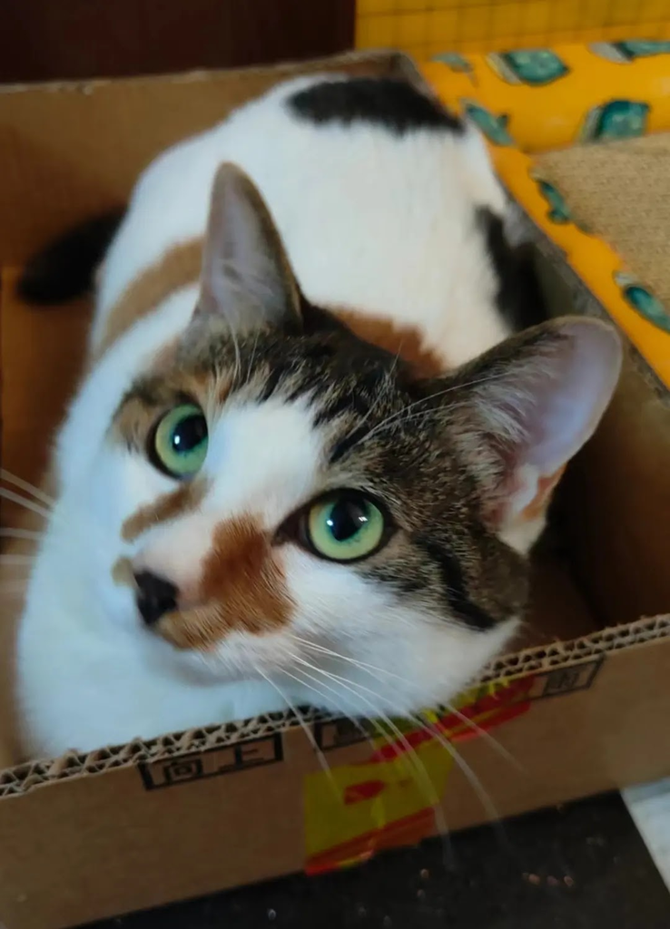

This is Daji my loved Cat :)

## Playing in the band (tables)

You can see data sets that are available to you (either in base R or in your packages) by typing `data()` in your console. Data that are in these packages can be called just by typing their name.

We’ll look at the `band_instruments` data set, which is in the dplyr package. Insert a new R code chunk and type the name of the data set to print its contents.

```r
band_instruments
```

```
## # A tibble: 3 × 2
##   name  plays
##   <chr> <chr>
## 1 John  guitar
## 2 Paul  bass
## 3 Keith guitar
```

What if we wanted to see this as a nice html table though? There are a few options for doing so. Most are awful to deal with. I like using `knitr::kable()`:

```r
knitr::kable(band_instruments)
```

| name | plays |
| --- | --- |
| John | guitar |
| Paul | bass |
| Keith | guitar |

### Nicer tables with kableExtra

Now let’s make a nicer table using the tools in the library kableExtra. We can use `kableExtra::kable_styling()` to modify our table.

```r
band_kable <-
  knitr::kable(band_instruments,
               format = 'html')

kableExtra::kable_styling(band_kable, 'striped')
```

| name | plays |
| --- | --- |
| John | guitar |
| Paul | bass |
| Keith | guitar |

### Even nicer tables with the Data table package

Another option, which is a preference of mine, is to use `DT::datatable`. DT is a package that provides an R interface to the JavaScript DataTables library.

```r
DT::datatable(band_instruments)
```

|  | name | plays |
| --- | --- | --- |
| 1 | John | guitar |
| 2 | Paul | bass |
| 3 | Keith | guitar |

It’s a little silly in this context. We have a search box and pagination for a table with only three rows. The great thing about the DataTables JavaScript package is that you’ve got tons of controls. Here, I’ll remove the paging and search feature:

```r
DT::datatable(band_instruments,
              options = list(paging = FALSE,
                             searching = FALSE))
```

|  | name | plays |
| --- | --- | --- |
| 1 | John | guitar |
| 2 | Paul | bass |
| 3 | Keith | guitar |

Use `data(package = 'ggplot2')` to see what data sets are in ggplot. I found the data set `mpg` – that’s a pretty good one for this example. It has fuel economy data for cars for 1999 and 2008.

```r
mpg
```

```
## # A tibble: 234 × 11
##    manufacturer model      displ  year   cyl trans drv     cty   hwy fl    class
##    <chr>        <chr>      <dbl> <int> <int> <chr> <chr> <int> <int> <chr> <chr>
##  1 audi         a4           1.8  1999     4 auto… f        18    29 p     comp…
##  2 audi         a4           1.8  1999     4 manu… f        21    29 p     comp…
##  3 audi         a4           2    2008     4 manu… f        20    31 p     comp…
##  4 audi         a4           2    2008     4 auto… f        21    30 p     comp…
##  5 audi         a4           2.8  1999     6 auto… f        16    26 p     comp…
##  6 audi         a4           2.8  1999     6 manu… f        18    26 p     comp…
##  7 audi         a4           3.1  2008     6 auto… f        18    27 p     comp…
##  8 audi         a4 quattro   1.8  1999     4 manu… 4        18    26 p     comp…
##  9 audi         a4 quattro   1.8  1999     4 auto… 4        16    25 p     comp…
## 10 audi         a4 quattro   2    2008     4 manu… 4        20    28 p     comp…
## # … with 224 more rows
```

Add a code chunk that uses `DT::datatable()` to print the `mpg` data frame into an html table. Provide the unique label, of your choice, to the chunk. **[1.0 points]**

```r
DT::datatable(mpg,
              style = "bootstrap4")
```

|  | manufacturer | model | displ | year | cyl | trans | drv | cty | hwy | fl | class |
| --- | --- | --- | --- | --- | --- | --- | --- | --- | --- | --- | --- |
| 1 | audi | a4 | 1.8 | 1999 | 4 | auto(l5) | f | 18 | 29 | p | compact |
| 2 | audi | a4 | 1.8 | 1999 | 4 | manual(m5) | f | 21 | 29 | p | compact |
| 3 | audi | a4 | 2 | 2008 | 4 | manual(m6) | f | 20 | 31 | p | compact |
| 4 | audi | a4 | 2 | 2008 | 4 | auto(av) | f | 21 | 30 | p | compact |
| 5 | audi | a4 | 2.8 | 1999 | 6 | auto(l5) | f | 16 | 26 | p | compact |
| 6 | audi | a4 | 2.8 | 1999 | 6 | manual(m5) | f | 18 | 26 | p | compact |
| 7 | audi | a4 | 3.1 | 2008 | 6 | auto(av) | f | 18 | 27 | p | compact |
| 8 | audi | a4 quattro | 1.8 | 1999 | 4 | manual(m5) | 4 | 18 | 26 | p | compact |
| 9 | audi | a4 quattro | 1.8 | 1999 | 4 | auto(l5) | 4 | 16 | 25 | p | compact |
| 10 | audi | a4 quattro | 2 | 2008 | 4 | manual(m6) | 4 | 20 | 28 | p | compact |

[output cut: 224 more lines]

I tried another style here!